# Estimating TVP-VARs with MSV using Efficient Importance Sampling

October, 2017

## Contents

[figure not shown]

1. TVP-VARs with MSV
2. Some existing models
   - (Cogley and Sargent 2001), (Cogley and Sargent 2005) and (Primiceri 2005)
   - (Philipov and Glickman 2006b) and (Philipov and Glickman 2006a)
3. (Efficient) Importance Sampling
4. Next steps

## TVP-VAR with MSV

Consider the following state-space representation of a TVP-VAR with MSV:

\[ \begin{eqnarray} y_t &= Z_t\alpha_t + \epsilon_t \qquad \epsilon_t \sim \mathcal{N}_k(\mathbf{0}_k, \Omega_t^{-1}) &\text{(measure eq.)}\tag{01}\\ \alpha_t &= \alpha_{t-1}+u_t \qquad u_t \sim \mathcal{N}_p(\mathbf{0}_p, Q) & \text{(state transition eq.)}\tag{02} \end{eqnarray} \]

Some remarks:

- We don't observe \(\alpha_t\) directly (latent variable);
- If \(\Omega_t^{-1}\) were non stochastic, the Kalman Filter could be used to obtain the ML function;
  - Since it is not the case, we have an analytically intractable high-dimensional integral.

## Cogley and Sargent (2001,2005)

- Their first work was a TVP-VAR of the form:
- \[ \begin{eqnarray} y_t &= Z_t\alpha_t + \epsilon_t \qquad \epsilon_t \sim \mathcal{N}_k(\mathbf{0}_k, R) \tag{03}\\ \alpha_t &= \alpha_{t-1}+u_t \qquad u_t \sim \mathcal{N}_p(\mathbf{0}_p, Q) \tag{04} \end{eqnarray} \]
- After being criticized in (2001) for the lack of MVS in their model, C&S proposed changing \(\epsilon_t\) in (03) for \(\epsilon_t = R_t^{1/2}\xi_t\), where \(\xi_t\) follows a standard normal distribution and \(R_t = B^{-1}H_tB^{-1'}\) with:
- \[ B = \begin{bmatrix} 1 & 0 & \cdots & 0 \\ \beta_{21} & 1 & \cdots & 0\\ \vdots & \vdots & \ddots & \vdots \\ \beta_{k1} & \beta_{k2} & \cdots & 1 \end{bmatrix} \quad H_t = \begin{bmatrix} h_{1t} & 0 & \cdots & 0 \\ 0 & h_{2t} & \cdots & 0\\ \vdots & \vdots & \ddots & \vdots \\ 0 & 0 & \cdots & h_{kt} \end{bmatrix} \]
- The elements of \(H\) follow driftless, geometric random walks of the form: \[ln(h_{it})=ln(h_{it-1})+\sigma_i \eta_{it}, \quad \eta_{it} \sim \mathcal{N}(0,1).\]

## Primiceri(2005)

- Proposed the same specification as (Cogley and Sargent 2005) but allowed the covariances in \(B\) to evolve over time:
- \[ B_t = \begin{bmatrix} 1 & 0 & \cdots & 0 \\ \beta_{21,t} & 1 & \cdots & 0\\ \vdots & \vdots & \ddots & \vdots \\ \beta_{k1,t} & \beta_{k2,t} & \cdots & 1 \end{bmatrix} \qquad \text{with } \beta_t = \beta_{t-1} + \upsilon_t\tag{05} \]
  - where \(\upsilon_t\) are mean-zero normal errors with constant covariance matrix.
- Drawback: *(05) is not invariant to the observable variables (\(y_t\)) order!*
  - The problem lies in the MSV structure.

## Wishart MSV models

- (Philipov and Glickman 2006b) and (Philipov and Glickman 2006a) proposes the following specification:
- \[ \Omega_t | \Omega_{t-1} \sim \mathcal{W}(\nu, S_{t-1}),\quad \text{with } \ S_t = \frac{1}{\nu}A^{1/2}\Omega_t^d A^{1/2'} \tag{06} \]
  - where \(A\) is a positive definite symmetric matrix containing parameters determining the intertemporal sensitivity of each element of the precision matrix and \(d \in [0,1)\) is a scalar that accounts for overall persistence of the process.
- This model is invariant to ordering!

## Proposal

[figure not shown]

We can incorporate the Wishart MSV à la (Philipov and Glickman 2006b) in a TVP-VAR structure!

## Proposal

The proposed model is:

\[ \begin{eqnarray} y_t &= Z_t\alpha_t + \epsilon_t, \quad \epsilon_t \sim \mathcal{N}_k(\mathbf{0}_k, \Omega_t^{-1}) \tag{01}\\ \alpha_t &= \alpha_{t-1}+u_t, \quad u_t \sim \mathcal{N}_p(\mathbf{0}_p, Q) \tag{02} \\ \Omega_t | \Omega_{t-1} &\sim \mathcal{W}_k\left(\nu, \frac{1}{\nu}\ A^{1/2} \ \Omega_{t-1}^d \ A^{1/2'} \right) \tag{06}. \end{eqnarray} \]

- Which leads to the following likelihood form:
- \[ L_\theta = \int \int \prod\limits_{t=1}^T g_\theta(y_t|\Omega_t, \alpha_t)p_\theta(\alpha_t|\alpha_{t-1})p_\theta(\Omega_t|\Omega_{t-1})d\alpha_T\ d\Omega_T, \]
  - for a given sequence \(\Omega_T\), the Kalman Filter can be used and the problem is simplified to:
- \[ L_\theta = \int \prod\limits_{t=1}^T g_\theta(y_t|y_{t-1}, \Omega_t)\ p_\theta(\Omega_t|\Omega_{t-1})\ d\Omega_T. \]
- But even with the simplification, estimation is still a challenge…

## Importance sampling

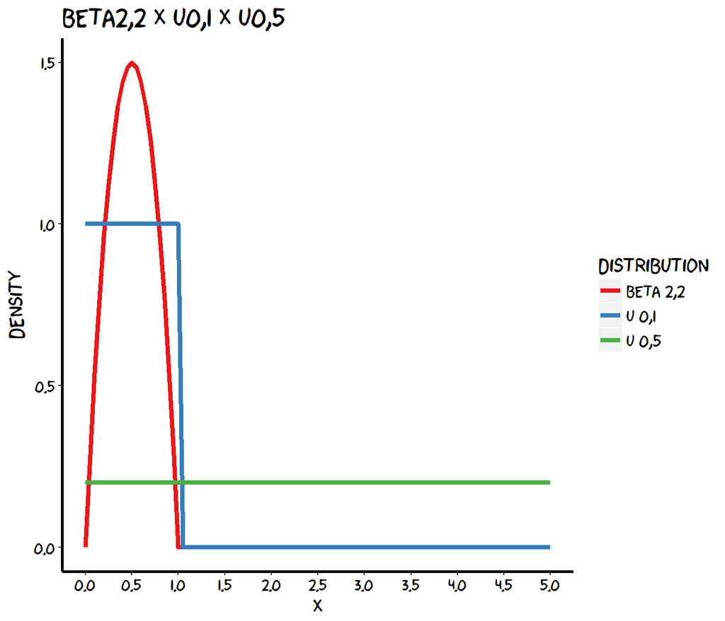

## Efficient Importance Sampling

- There are two major questions when working with IS:
  1. Choosing a parametric class of estimators \(\mathcal{M}\);
  2. Finding the best parameters that minimize the Monte Carlo variance;
- EIS (Richard and Zhang 2007) provides a way to solve (2);
  - Choosing \(\mathcal{M}\) whithin the exponential family gives the advantage to simplify the algorithm to a sequence of OLS estimates;
  - Since the problem posed is a high dimension integral, we are going to use the *sequencial* form of EIS.

## References

Cogley, Timothy, and Thomas J Sargent. 2005. “Drifts and Volatilities: Monetary Policies and Outcomes in the Post Wwii Us.” *Review of Economic Dynamics* 8 (2). Elsevier: 262–302.

Cogley, Timothy, and Thomas J. Sargent. 2001. “Evolving Post-World War II U.S. Inflation Dynamics.” *NBER Macroeconomics Annual* 16 (1): 331–73.

Philipov, Alexander, and Mark E Glickman. 2006a. “Factor Multivariate Stochastic Volatility via Wishart Processes.” *Econometric Reviews* 25 (2-3). Taylor & Francis: 311–34.

———. 2006b. “Multivariate Stochastic Volatility via Wishart Processes.” *Journal of Business & Economic Statistics* 24 (3). Taylor & Francis: 313–28.

Primiceri, Giorgio E. 2005. “Time Varying Structural Vector Autoregressions and Monetary Policy.” *The Review of Economic Studies* 72 (3). Wiley-Blackwell: 821–52.

Richard, Jean-Francois, and Wei Zhang. 2007. “Efficient High-Dimensional Importance Sampling.” *Journal of Econometrics* 141 (2). Elsevier: 1385–1411.